# Etapa 4 — Incorporación y selección de rezagos para SAIDI

Edwin Silva Salas

2026-09-17

# ⚠️ Nota de alcance metodológico

Al igual que en `Etapa4_01_feature_engineering_general.Rmd`, `SAIDI` en este documento es la aproximación provisional (`SAIDI ≈ duracion_total`), **no** la fórmula oficial con el denominador de usuarios totales. Los resultados de este documento (persistencia temporal, rezagos óptimos) son válidos como evidencia de la dinámica temporal del fenómeno, pero deben re-verificarse sobre `D_mod` con la fórmula oficial antes de citarse como resultado final de la tesis.

# 1. Objetivo

El objetivo de esta sección es incorporar y seleccionar variables rezagadas que permitan capturar la dinámica temporal del indicador SAIDI (duración promedio de interrupciones), así como los efectos diferidos de las variables climáticas sobre la duración de las fallas.

A diferencia de SAIFI, SAIDI es una variable continua, lo que permite su modelación mediante enfoques de regresión lineal dinámica.

# 2. Justificación econométrica

En su forma estática, el modelo se define como:

$$SAIDI_t = X_t \beta +
\epsilon_t$$

Sin embargo, la duración de las interrupciones puede depender de condiciones pasadas del sistema, por lo que se propone una especificación dinámica:

$$SAIDI_t = X_t \beta + \gamma SAIDI_{t-1}
+ \delta X_{t-1} + \epsilon_t$$

Esto permite capturar:

- Persistencia en la duración de interrupciones
- Efectos acumulativos del clima
- Dinámica operativa del sistema

# 3. Evidencia empírica de dependencia temporal

## Preparación

```r
library(dplyr)
library(ggplot2)
library(lubridate)
library(readr)
library(tidyr)
library(readxl)
```

## Entorno (.env)

```r
buscar_env <- function() {
  candidatos <- c(".env", file.path("..", ".env"), file.path("..", "..", ".env"),
                  file.path("..", "..", "..", ".env"), file.path("..", "..", "..", "..", ".env"))
  existentes <- candidatos[file.exists(candidatos)]
  if (length(existentes) == 0) return(NA_character_)
  existentes[1]
}
ruta_env <- buscar_env()
if (!is.na(ruta_env)) {
  readRenviron(ruta_env)
} else {
  warning("No se encontró un archivo .env. Copia .env.example como .env y ajusta UBICACION_DATA.")
}

UBICACION_DATA <- Sys.getenv("UBICACION_DATA")
if (UBICACION_DATA == "") {
  stop("UBICACION_DATA no esta definida. Verifica el archivo .env.")
}
cat(sprintf("UBICACION_DATA: %s\n", UBICACION_DATA))
```

```
## UBICACION_DATA: D:/OneDrive - PUJ Cali/Projecto_Grado_Javeriana/Data_Project/
```

## Carga de datos

Se recarga el panel con rezagos climáticos ya construido en `Etapa4_01_feature_engineering_general.Rmd`.

```r
panel_semana <- readRDS(file.path(UBICACION_DATA, "panel_semana_con_rezagos.rds"))
head(panel_semana)
```

```
## # A tibble: 6 × 24
##   id_cuadrante semana              temp_media_semana temp_max_semana
##          <dbl> <dttm>                          <dbl>           <dbl>
## 1            1 2020-12-28 00:00:00              13.6            19.0
## 2            1 2021-02-15 00:00:00              13.7            20.8
## 3            1 2021-02-22 00:00:00              14.1            20.4
## 4            1 2021-05-03 00:00:00              14.2            21.8
## 5            1 2021-06-28 00:00:00              15.0            22.5
## 6            1 2021-08-30 00:00:00              15.7            24.9
## # ℹ 20 more variables: temp_min_semana <dbl>, precip_total_semana <dbl>,
## #   humedad_media_semana <dbl>, viento_medio_semana <dbl>,
## #   viento_max_semana <dbl>, lluvia_intensa <int>, calor_extremo <int>,
## #   viento_fuerte <int>, longitud <dbl>, latitud <dbl>, n_eventos <int>,
## #   duracion_total <dbl>, duracion_promedio <dbl>, evento_extremo <int>,
## #   falla <int>, SAIFI <int>, SAIDI <dbl>, lluvia_lag1 <dbl>,
## #   viento_lag1 <dbl>, eventos_lag1 <int>
```

## 3.1 Persistencia en la duración

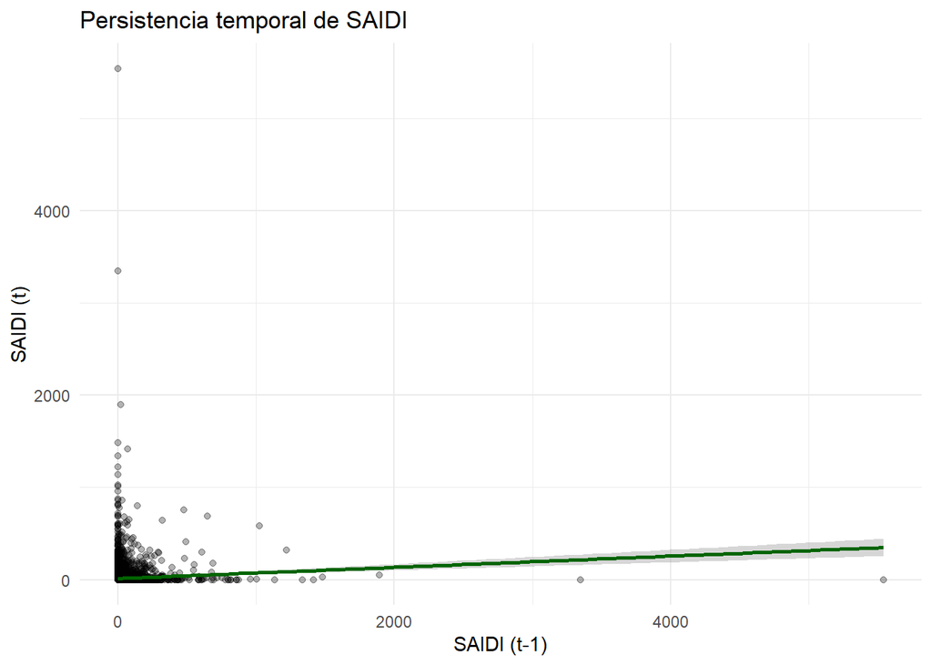

```r
ggplot(panel_semana, aes(x = lag(SAIDI, 1), y = SAIDI)) +
  geom_point(alpha = 0.3) +
  geom_smooth(method = "lm", color = "darkgreen") +
  labs(
    title = "Persistencia temporal de SAIDI",
    x = "SAIDI (t-1)",
    y = "SAIDI (t)"
  ) +
  theme_minimal()
```

Se observa una relación positiva que sugiere dependencia temporal en la duración de interrupciones.

## 3.2 Efecto rezagado de la precipitación

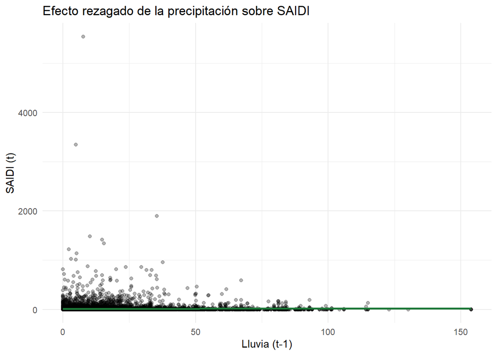

```r
ggplot(panel_semana, aes(x = lluvia_lag1, y = SAIDI)) +
  geom_point(alpha = 0.3) +
  geom_smooth(method = "lm", color = "#1b7837") +
  labs(
    title = "Efecto rezagado de la precipitación sobre SAIDI",
    x = "Lluvia (t-1)",
    y = "SAIDI (t)"
  ) +
  theme_minimal()
```

## 3.3 Serie temporal por cuadrante (ejemplo)

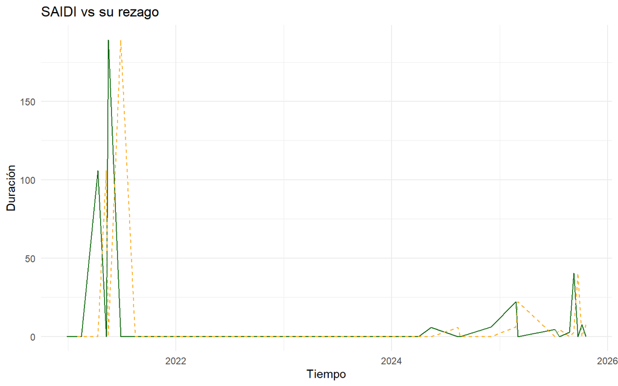

```r
ejemplo <- panel_semana %>%
  filter(id_cuadrante == 3)

ggplot(ejemplo, aes(x = semana)) +
  geom_line(aes(y = SAIDI), color = "darkgreen") +
  geom_line(aes(y = lag(SAIDI, 1)), color = "orange", linetype = "dashed") +
  labs(
    title = "SAIDI vs su rezago",
    y = "Duración",
    x = "Tiempo"
  ) +
  theme_minimal()
```

## 3.4 Correlación temporal

Valores positivos indican persistencia temporal.

```r
cor(panel_semana$SAIDI,
    dplyr::lag(panel_semana$SAIDI, 1),
    use = "complete.obs")
```

```
## [1] 0.06078904
```

## 3.5 Autocorrelación

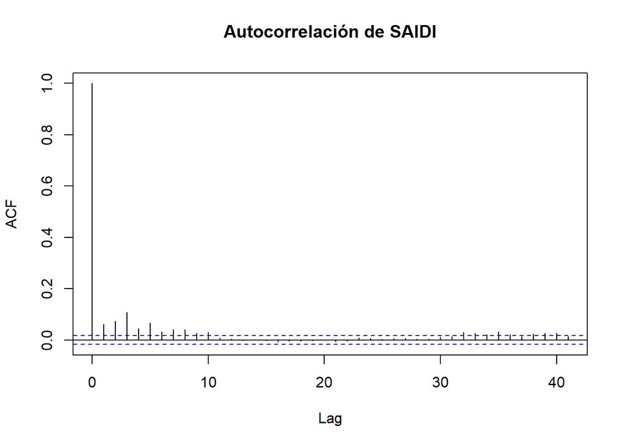

```r
acf(panel_semana$SAIDI, na.action = na.omit,
    main = "Autocorrelación de SAIDI")
```

# 4. Construcción de rezagos

```r
panel_semana <- panel_semana %>%
  arrange(id_cuadrante, semana) %>%
  group_by(id_cuadrante) %>%
  mutate(
    SAIDI_lag1 = lag(SAIDI, 1),
    SAIDI_lag2 = lag(SAIDI, 2),
    SAIDI_lag3 = lag(SAIDI, 3),

    lluvia_lag1 = lag(precip_total_semana, 1),
    lluvia_lag2 = lag(precip_total_semana, 2),

    viento_lag1 = lag(viento_max_semana, 1),
    viento_lag2 = lag(viento_max_semana, 2)
  ) %>%
  ungroup()
```

# 5. Selección de rezagos óptimos

## 5.1 Modelo completo

```r
modelo_full_saidi <- lm(
  SAIDI ~ precip_total_semana + viento_max_semana +
    temp_media_semana + humedad_media_semana +
    SAIDI_lag1 + SAIDI_lag2 + SAIDI_lag3 +
    lluvia_lag1 + lluvia_lag2 +
    viento_lag1,
  data = panel_semana
)

summary(modelo_full_saidi)
```

```
##
## Call:
## lm(formula = SAIDI ~ precip_total_semana + viento_max_semana +
##     temp_media_semana + humedad_media_semana + SAIDI_lag1 + SAIDI_lag2 +
##     SAIDI_lag3 + lluvia_lag1 + lluvia_lag2 + viento_lag1, data = panel_semana)
##
## Residuals:
##    Min     1Q Median     3Q    Max
## -612.1  -15.3   -9.9   -3.8 5441.1
##
## Coefficients:
##                        Estimate Std. Error t value Pr(>|t|)
## (Intercept)          -1.273e+02  2.022e+01  -6.295 3.19e-10 ***
## precip_total_semana  -1.266e-03  5.201e-02  -0.024  0.98059
## viento_max_semana     5.627e+00  2.077e+00   2.710  0.00674 **
## temp_media_semana     2.929e+00  4.263e-01   6.871 6.67e-12 ***
## humedad_media_semana  7.781e-01  1.475e-01   5.274 1.36e-07 ***
## SAIDI_lag1            4.500e-02  9.142e-03   4.922 8.68e-07 ***
## SAIDI_lag2            6.663e-02  9.220e-03   7.227 5.25e-13 ***
## SAIDI_lag3            1.095e-01  9.431e-03  11.612  < 2e-16 ***
## lluvia_lag1          -8.465e-03  4.472e-02  -0.189  0.84986
## lluvia_lag2           4.752e-02  4.274e-02   1.112  0.26628
## viento_lag1           4.650e+00  2.013e+00   2.310  0.02090 *
## ---
## Signif. codes:  0 '***' 0.001 '**' 0.01 '*' 0.05 '.' 0.1 ' ' 1
##
## Residual standard error: 84.98 on 12057 degrees of freedom
##   (1032 observations deleted due to missingness)
## Multiple R-squared:  0.02566,    Adjusted R-squared:  0.02485
## F-statistic: 31.75 on 10 and 12057 DF,  p-value: < 2.2e-16
```

## 5.2 Selección automática (AIC)

```r
modelo_step_saidi <- step(modelo_full_saidi, direction = "both")
```

```
## Start:  AIC=107234.1
## SAIDI ~ precip_total_semana + viento_max_semana + temp_media_semana +
##     humedad_media_semana + SAIDI_lag1 + SAIDI_lag2 + SAIDI_lag3 +
##     lluvia_lag1 + lluvia_lag2 + viento_lag1
##
##                        Df Sum of Sq      RSS    AIC
## - precip_total_semana   1         4 87077515 107232
## - lluvia_lag1           1       259 87077770 107232
## - lluvia_lag2           1      8926 87086437 107233
## <none>                              87077511 107234
## - viento_lag1           1     38542 87116053 107237
## - viento_max_semana     1     53034 87130545 107239
## - SAIDI_lag1            1    174960 87252471 107256
## - humedad_media_semana  1    200896 87278407 107260
## - temp_media_semana     1    341002 87418513 107279
## - SAIDI_lag2            1    377172 87454683 107284
## - SAIDI_lag3            1    973810 88051321 107366
##
## Step:  AIC=107232.1
## SAIDI ~ viento_max_semana + temp_media_semana + humedad_media_semana +
##     SAIDI_lag1 + SAIDI_lag2 + SAIDI_lag3 + lluvia_lag1 + lluvia_lag2 +
##     viento_lag1
##
##                        Df Sum of Sq      RSS    AIC
## - lluvia_lag1           1       258 87077773 107230
## - lluvia_lag2           1      8938 87086453 107231
## <none>                              87077515 107232
## + precip_total_semana   1         4 87077511 107234
## - viento_lag1           1     38816 87116331 107235
## - viento_max_semana     1     53260 87130775 107237
## - SAIDI_lag1            1    175092 87252608 107254
## - humedad_media_semana  1    280854 87358369 107269
## - temp_media_semana     1    367586 87445102 107281
## - SAIDI_lag2            1    377421 87454936 107282
## - SAIDI_lag3            1    974094 88051609 107364
##
## Step:  AIC=107230.1
## SAIDI ~ viento_max_semana + temp_media_semana + humedad_media_semana +
##     SAIDI_lag1 + SAIDI_lag2 + SAIDI_lag3 + lluvia_lag2 + viento_lag1
##
```

[output cut: 14 more lines]

```
## SAIDI ~ viento_max_semana + temp_media_semana + humedad_media_semana +
##     SAIDI_lag1 + SAIDI_lag2 + SAIDI_lag3 + viento_lag1
##
##                        Df Sum of Sq      RSS    AIC
## <none>                              87086479 107229
## + lluvia_lag2           1      8706 87077773 107230
## + lluvia_lag1           1        26 87086453 107231
## + precip_total_semana   1        16 87086463 107231
## - viento_lag1           1     39669 87126148 107233
## - viento_max_semana     1     54341 87140820 107235
## - SAIDI_lag1            1    175008 87261487 107252
## - humedad_media_semana  1    329490 87415968 107273
## - temp_media_semana     1    371121 87457599 107279
## - SAIDI_lag2            1    380660 87467138 107280
## - SAIDI_lag3            1    975918 88062397 107362
```

```r
summary(modelo_step_saidi)
```

```
##
## Call:
## lm(formula = SAIDI ~ viento_max_semana + temp_media_semana +
##     humedad_media_semana + SAIDI_lag1 + SAIDI_lag2 + SAIDI_lag3 +
##     viento_lag1, data = panel_semana)
##
## Residuals:
##    Min     1Q Median     3Q    Max
## -612.5  -15.3   -9.9   -3.9 5441.0
##
## Coefficients:
##                        Estimate Std. Error t value Pr(>|t|)
## (Intercept)          -1.280e+02  1.859e+01  -6.887 5.99e-12 ***
## viento_max_semana     5.621e+00  2.049e+00   2.743  0.00609 **
## temp_media_semana     2.935e+00  4.094e-01   7.169 8.00e-13 ***
## humedad_media_semana  7.961e-01  1.179e-01   6.755 1.49e-11 ***
## SAIDI_lag1            4.498e-02  9.137e-03   4.923 8.64e-07 ***
## SAIDI_lag2            6.689e-02  9.214e-03   7.261 4.09e-13 ***
## SAIDI_lag3            1.096e-01  9.428e-03  11.625  < 2e-16 ***
## viento_lag1           4.598e+00  1.962e+00   2.344  0.01910 *
## ---
## Signif. codes:  0 '***' 0.001 '**' 0.01 '*' 0.05 '.' 0.1 ' ' 1
##
## Residual standard error: 84.98 on 12060 degrees of freedom
##   (1032 observations deleted due to missingness)
## Multiple R-squared:  0.02556,    Adjusted R-squared:  0.02499
## F-statistic: 45.19 on 7 and 12060 DF,  p-value: < 2.2e-16
```

## 5.3 Comparación

```r
AIC(modelo_full_saidi, modelo_step_saidi)
```

```
##                   df      AIC
## modelo_full_saidi 12 141483.6
## modelo_step_saidi  9 141478.8
```

```r
BIC(modelo_full_saidi, modelo_step_saidi)
```

```
##                   df      BIC
## modelo_full_saidi 12 141572.4
## modelo_step_saidi  9 141545.4
```

## 5.4 Variables relevantes

```r
coef(summary(modelo_step_saidi))
```

```
##                           Estimate   Std. Error   t value     Pr(>|t|)
## (Intercept)          -127.99095391 18.585076369 -6.886760 5.991112e-12
## viento_max_semana       5.62145049  2.049211905  2.743226 6.092874e-03
## temp_media_semana       2.93497441  0.409400617  7.168955 7.998201e-13
## humedad_media_semana    0.79612664  0.117859080  6.754903 1.494979e-11
## SAIDI_lag1              0.04498323  0.009137425  4.922966 8.637040e-07
## SAIDI_lag2              0.06689498  0.009213548  7.260502 4.093408e-13
## SAIDI_lag3              0.10960774  0.009428360 11.625324 4.487033e-31
## viento_lag1             4.59752792  1.961544622  2.343830 1.910300e-02
```

# 6. Interpretación de resultados

# 7. Implicaciones metodológicas

La inclusión de rezagos convierte el modelo en una regresión lineal dinámica, lo cual mejora la capacidad explicativa del modelo. Sin embargo, se reconoce que la inclusión de variables rezagadas puede generar correlación con el término de error, lo cual constituye una limitación desde el punto de vista causal.

# 8. Conclusión

```r
modelo_test <- lm(
  SAIDI ~ precip_total_semana + lluvia_lag1 + lluvia_lag2,
  data = panel_semana
)

summary(modelo_test)
```

```
##
## Call:
## lm(formula = SAIDI ~ precip_total_semana + lluvia_lag1 + lluvia_lag2,
##     data = panel_semana)
##
## Residuals:
##    Min     1Q Median     3Q    Max
##  -27.1  -14.5  -12.7  -11.5 5524.5
##
## Coefficients:
##                      Estimate Std. Error t value Pr(>|t|)
## (Intercept)         11.514436   1.225989   9.392   <2e-16 ***
## precip_total_semana  0.079706   0.041163   1.936   0.0529 .
## lluvia_lag1          0.004781   0.041846   0.114   0.9090
## lluvia_lag2          0.070355   0.041705   1.687   0.0916 .
## ---
## Signif. codes:  0 '***' 0.001 '**' 0.01 '*' 0.05 '.' 0.1 ' ' 1
##
## Residual standard error: 84.88 on 12408 degrees of freedom
##   (688 observations deleted due to missingness)
## Multiple R-squared:  0.0006755,  Adjusted R-squared:  0.0004339
## F-statistic: 2.796 on 3 and 12408 DF,  p-value: 0.03869
```

# 9. Comparación: modelo con vs. sin rezagos

```r
library(Metrics)
library(knitr)
```

## 9.1 Definir modelos

```r
df_model <- panel_semana %>%
  dplyr::select(
    SAIDI,
    precip_total_semana, viento_max_semana,
    temp_media_semana, humedad_media_semana,
    lluvia_intensa, viento_fuerte,
    SAIDI_lag1, SAIDI_lag2, SAIDI_lag3,
    lluvia_lag2, viento_lag1
  ) %>%
  na.omit()

# Modelo SIN rezagos
modelo_sin_lags <- lm(
  SAIDI ~ precip_total_semana + viento_max_semana +
    temp_media_semana + humedad_media_semana +
    lluvia_intensa + viento_fuerte,
  data = df_model
)

# Modelo CON rezagos
modelo_con_lags <- lm(
  SAIDI ~ temp_media_semana + humedad_media_semana +
    SAIDI_lag1 + SAIDI_lag2 + SAIDI_lag3 +
    lluvia_lag2 + viento_lag1,
  data = df_model
)
```

## 9.2 Predicciones

```r
pred_sin <- predict(modelo_sin_lags, df_model)
pred_con <- predict(modelo_con_lags, df_model)
```

## 9.3 Métricas de desempeño

```r
rmse_sin <- rmse(df_model$SAIDI, pred_sin)
mae_sin  <- mae(df_model$SAIDI, pred_sin)
r2_sin   <- summary(modelo_sin_lags)$r.squared

rmse_con <- rmse(df_model$SAIDI, pred_con)
mae_con  <- mae(df_model$SAIDI, pred_con)
r2_con   <- summary(modelo_con_lags)$r.squared
```

## 9.4 Tabla comparativa

```r
tabla_modelos <- data.frame(
  Modelo = c("Sin rezagos", "Con rezagos"),
  RMSE = c(rmse_sin, rmse_con),
  MAE  = c(mae_sin, mae_con),
  R2   = c(r2_sin, r2_con)
)

kable(tabla_modelos, digits = 3, caption = "Comparación de modelos SAIDI: con vs sin rezagos")
```

Comparación de modelos SAIDI: con vs sin rezagos

| Modelo | RMSE | MAE | R2 |
| --- | --- | --- | --- |
| Sin rezagos | 85.782 | 22.538 | 0.006 |
| Con rezagos | 84.971 | 21.737 | 0.025 |

**Cómo interpretar la tabla:** si la inclusión de rezagos mejora significativamente RMSE/MAE, evidencia la importancia de la dinámica temporal en la explicación de la duración de interrupciones. Si el cambio es pequeño, también es válido decir que, aunque la mejora en métricas es moderada, los rezagos aportan interpretabilidad económica al capturar la persistencia del sistema.

# 10. Validación más rigurosa: train / test split temporal

```r
set.seed(123)

train <- panel_semana %>% filter(semana < as.Date("2024-01-01"))
test  <- panel_semana %>% filter(semana >= as.Date("2024-01-01"))

modelo_con_lags_train <- lm(
  SAIDI ~ temp_media_semana + humedad_media_semana +
    SAIDI_lag1 + SAIDI_lag2 + SAIDI_lag3 +
    lluvia_lag2 + viento_lag1,
  data = train
)

pred_test <- predict(modelo_con_lags_train, test)

rmse_test <- rmse(test$SAIDI, pred_test)
rmse_test
```

```
## [1] 117.0212
```